# Create 'scissors and paste' messages from Trove newspaper articles

When you search for a term in Trove's digitised newspapers and click on individual article, you'll see your search terms are highlighted. If you look at the code you'll see the highlighted box around the word includes its page coordinates. That means that if we search for a word, we can find where it appears on a page, and by cropping the page to those coordinates we can create an image of an individual word. By combining these images we can create scissors and paste style messages!

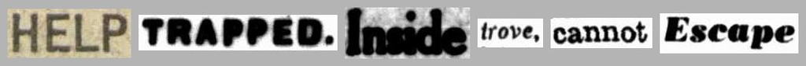

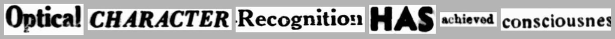

In this notebook you can create your own 'scissors and paste' messages:

1. Enter a word in the box below and click **Add word**.
2. Because of OCR errors the result might not be what you want, click **Retry last word** to make another attempt.
3. When you've finished adding words, click on the 'Download' link to save.
4. To start again click **Clear all**.

Some things to note:

- If you don't have a Trove API key, you can [get one here](https://trove.nla.gov.au/about/create-something/using-api).
- The article used to extract the word is chosen randomly from the first 100 search results and, if the word appears multiple times in an article, one instance is chosen at random. This mixes up the results so that **Retry last word** should produce something different.
- Short, common words like 'I' and 'a' don't seem to work very well, so it's probably easiest to just leave them out of your message. Who cares about grammar!

Created by [Tim Sherratt](https://timsherratt.org/) for the [GLAM Workbench](https://glam-workbench.github.io/).  
Support this project by becoming a [GitHub sponsor](https://github.com/sponsors/wragge?o=esb).